# Case Study: Diabetes Prediction

## Pima Indians Diabetes Database

This [*Pima Indians Diabetes Dataset*](https://www.kaggle.com/datasets/uciml/pima-indians-diabetes-database) is originally from the National Institute of Diabetes and Digestive and Kidney Diseases. The objective of the dataset is to diagnostically predict whether or not a patient has diabetes, based on certain diagnostic measurements included in the dataset.

### Content

The datasets consists of several medical predictor variables and one target variable, Outcome. Predictor variables includes the number of pregnancies the patient has had, their BMI, insulin level, age, and so on.

## Objective

Obtain a Bayesian inference of Diabetes using the Glucose values and implement a Logistic Bayesian Model for calculating the probability of a patient having Diabetes as a function of the different diagnostic measurements of each person in the dataset.

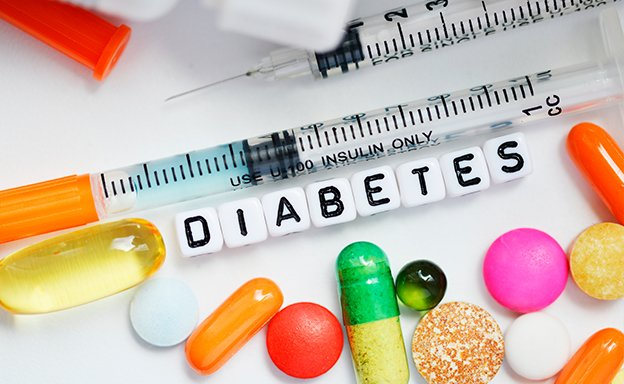

Diabetes

## Data Exploration of the Data

```r
data = read.csv("diabetes.csv")
attach(data)
head(data)
```

|  | Pregnancies | Glucose | BloodPressure | SkinThickness | Insulin | BMI | DiabetesPedigreeFunction | Age | Outcome |
| --- | --- | --- | --- | --- | --- | --- | --- | --- | --- |
| 1 | 6 | 148 | 72 | 35 | 0 | 33.6 | 0.627 | 50 | 1 |
| 2 | 1 | 85 | 66 | 29 | 0 | 26.6 | 0.351 | 31 | 0 |
| 3 | 8 | 183 | 64 | 0 | 0 | 23.3 | 0.672 | 32 | 1 |
| 4 | 1 | 89 | 66 | 23 | 94 | 28.1 | 0.167 | 21 | 0 |
| 5 | 0 | 137 | 40 | 35 | 168 | 43.1 | 2.288 | 33 | 1 |
| 6 | 5 | 116 | 74 | 0 | 0 | 25.6 | 0.201 | 30 | 0 |

```r
summary(data)
```

```
##   Pregnancies        Glucose      BloodPressure    SkinThickness
##  Min.   : 0.000   Min.   :  0.0   Min.   :  0.00   Min.   : 0.00
##  1st Qu.: 1.000   1st Qu.: 99.0   1st Qu.: 62.00   1st Qu.: 0.00
##  Median : 3.000   Median :117.0   Median : 72.00   Median :23.00
##  Mean   : 3.845   Mean   :120.9   Mean   : 69.11   Mean   :20.54
##  3rd Qu.: 6.000   3rd Qu.:140.2   3rd Qu.: 80.00   3rd Qu.:32.00
##  Max.   :17.000   Max.   :199.0   Max.   :122.00   Max.   :99.00
##     Insulin           BMI        DiabetesPedigreeFunction      Age
##  Min.   :  0.0   Min.   : 0.00   Min.   :0.0780           Min.   :21.00
##  1st Qu.:  0.0   1st Qu.:27.30   1st Qu.:0.2437           1st Qu.:24.00
##  Median : 30.5   Median :32.00   Median :0.3725           Median :29.00
##  Mean   : 79.8   Mean   :31.99   Mean   :0.4719           Mean   :33.24
##  3rd Qu.:127.2   3rd Qu.:36.60   3rd Qu.:0.6262           3rd Qu.:41.00
##  Max.   :846.0   Max.   :67.10   Max.   :2.4200           Max.   :81.00
##     Outcome
##  Min.   :0.000
##  1st Qu.:0.000
##  Median :0.000
##  Mean   :0.349
##  3rd Qu.:1.000
##  Max.   :1.000
```

The dataset contains:

- `Pregnancies`: shows the number of times the patient had been pregnant
- `Glucose`: shows the concentration of Glucose after 2 hours of oral glucose concentration in the glucose tolerance test (mg/dL)
- `BloodPressure`: Diastolic blood pressure (mm Hg)
- `SkinThickness`: Triceps skin fold thickness (mm)
- `Insulin`: 2-Hour serum insulin (mu U/ml)
- `BMI`: Body mass index
- `DiabetesPedigreeFunction`: The diabetes Pedigree Function
- `Age`: Age in years
- `Outcome`: 1 if has diabetes and 0 if not

```r
X = data[,-9]
y = as.factor(data$Outcome)
y.bin = ifelse(data$Outcome == 1, 1, 0)

VARS = names(X)
VARS
```

```
## [1] "Pregnancies"              "Glucose"
## [3] "BloodPressure"            "SkinThickness"
## [5] "Insulin"                  "BMI"
## [7] "DiabetesPedigreeFunction" "Age"
```

We can plot the distribution of all of the variables

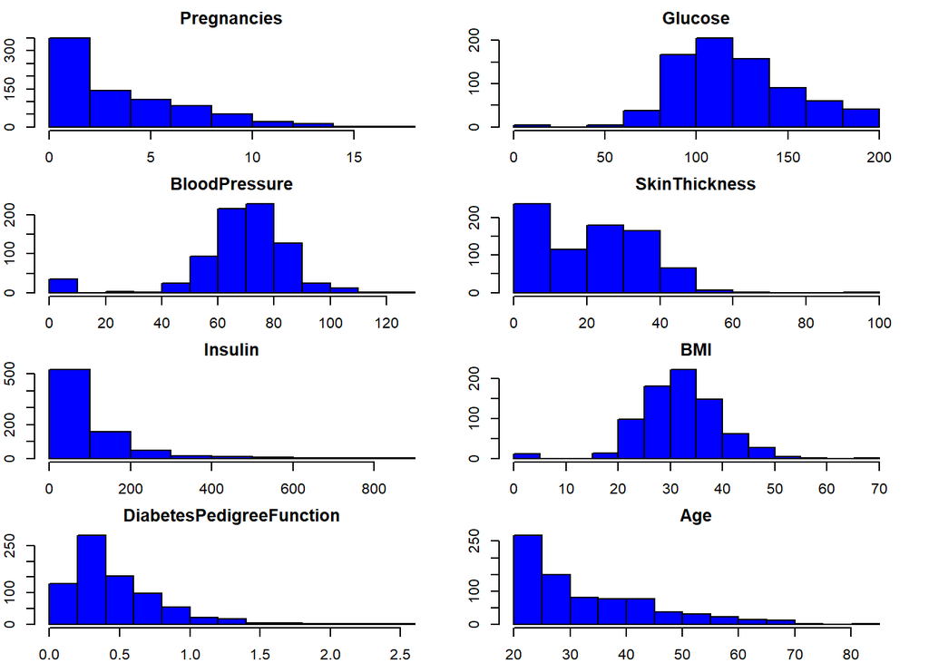

```r
par(mfrow=c(4,2))
par(mar = rep(2, 4))
for( i in 1:8){
  hist(X[,i], main = colnames(X)[i],xlab =     colnames(X)[i], col = 'blue')
}
```

## Bayesian Normal Model

As a first approach, we can observe that the Glucose kind of follows a similar distribution to a Normal distribution

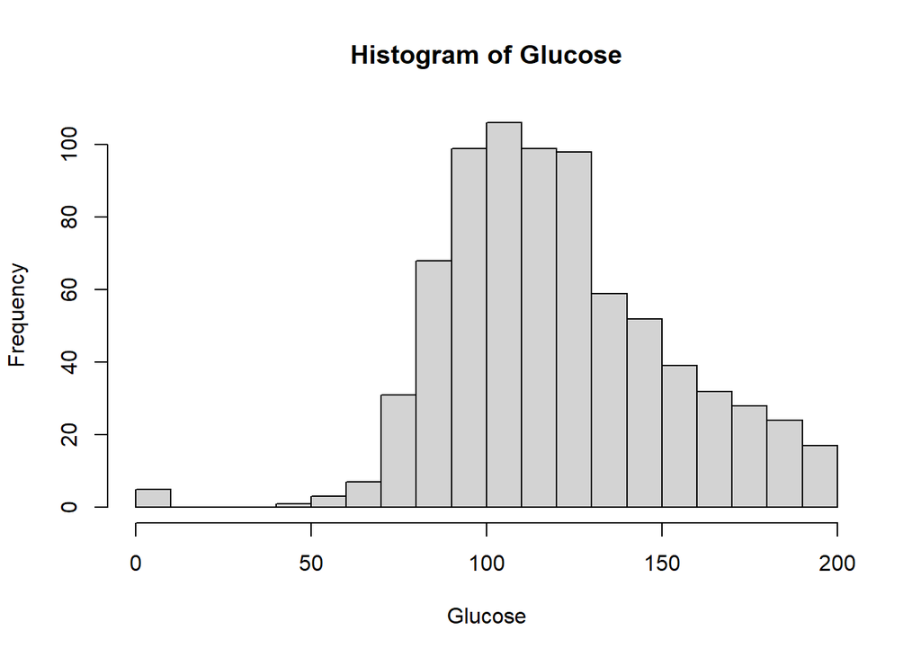

```r
hist(Glucose, breaks = 20)
```

But if we separate the Glucose of the people with Diabetes and the people with no diabetes, we can observe that the Glucose of people with no Diabetes follows a Normal Distribution, and is kind of separable from the Glucose distribution of diabetes patients

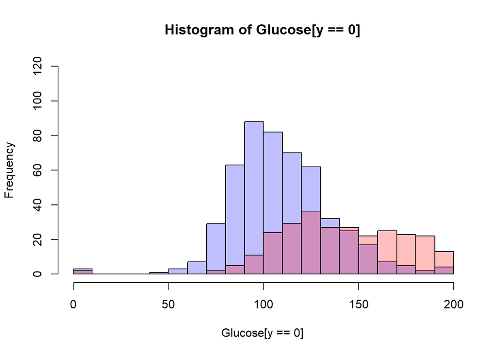

```r
par(mfrow=c(1,1))

hist(Glucose[y==0], col=rgb(0,0,1,1/4), xlim=c(0,max(Glucose)), ylim=c(0,120), breaks = 20)
hist(Glucose[y==1], col=rgb(1,0,0,1/4), add=T, breaks=20)
```

We know that Glucose is used to detect diabetic people, so we can use this knowledge to create a Bayesian Model.

With the assumption that the Glucose follows a Normal Distribution, we can obtain a predictive distribution of the Glucose levels of a non diabetic person, in order to evaluate extreme values of Glucose to detect anomalies, that can be classified as people with possible Diabetes.

### Bayesian Prediction of Glucose levels of non-diabetics patients

We will use a logarithm transformation in order to create a more Normal distribution:

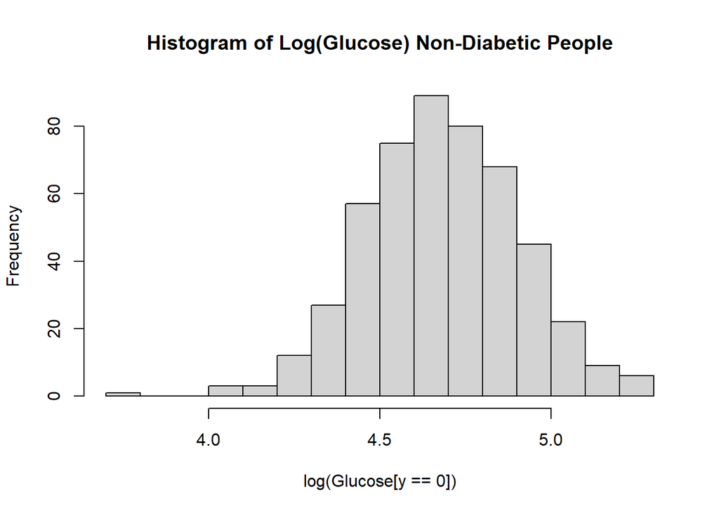

```r
hist(log(Glucose[y==0]), breaks=20, main="Histogram of Log(Glucose) Non-Diabetic People")
```

We will assume that the Glucose, $X$, follows a lognormal distribution:
$$X\mid\mu,\tau\sim \text{Lognormal}\left(\mu,\frac{1}{\tau}\right)$$
and we assume the conjugate prior distribution for the normal distribution, that is, a normal-gamma prior distribution:
$$\mu\mid\tau\sim \text{Normal}\left(m,\frac{1}{c\tau}\right)$$

$$\tau\sim\text{Gamma}\left(\frac{a}{2},\frac{b}{2}\right)$$

We set the prior parameters.We can use a non informative prior:

```r
m=0; c=0.01; a=0.01; b=0.01;
```

Given the Glucose $\text{data}=\left\{x_1,\ldots,x_n\right\}$, the posterior is equal to:
$$\mu\mid\tau,\text{data}\sim \text{Normal}\left(m^*,\frac{1}{c^*\tau}\right)$$
$$\tau\mid\text{data}\sim\text{Gamma}\left(\frac{a^*}{2},\frac{b^*}{2}\right)$$
where,
$$m^{\ast} =\frac{c m+n\bar{x}}{c+n},$$
$$c^{\ast}=c+n,$$
$$a^{\ast} =a+n,$$
$$b^{\ast} =b+\left( n-1\right) s^{2}+\frac{c n}{c+n}(m-\bar{x})^2$$

Calculate the observed data values:

```r
log.Gluc = log(Glucose[y==0][Glucose[y==0] > 0])
n=length(log.Gluc)
mean.gluc=mean(log.Gluc)
var.gluc=var(log.Gluc)
```

Compute the posterior values:

```r
m.ast=(c*m+n*mean.gluc)/(c+n)
c.ast=c+n
a.ast=a+n
b.ast=b+(n-1)*var.gluc+c*n*(m-mean.gluc)^2/(c+n)
```

We can compare the prior and the posterior joint distribution for the normal paremeters

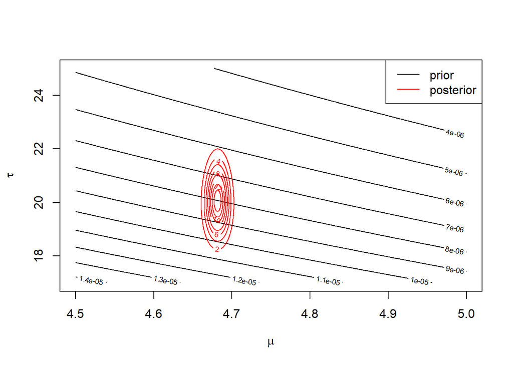

```r
library(nclbayes)
mu=seq(4.5,5,len=1000)
tau=seq(17,25,len=1000)
NGacontour(mu,tau,m,c,a,b)
NGacontour(mu,tau,m.ast,c.ast,a.ast,b.ast,add=TRUE,col="red")
legend("topright",c("prior","posterior"),lty=c(1,1),col=c("black","red"))
```

We obtained the join posterior distribution of the Gaussian parameters is:
$$\mu\mid\tau,\text{data}\sim\text{Normal}\left( 4.68,\frac{1}{497.01\tau}\right)$$

$$\tau\mid\text{data}\sim\text{Gamma}\left(\frac{ 497.01}{2},\frac{24.754}{2}\right)$$

We can use the Monte Carlo sampling, we may obtain a sample of size M=10000 from this join distribution:

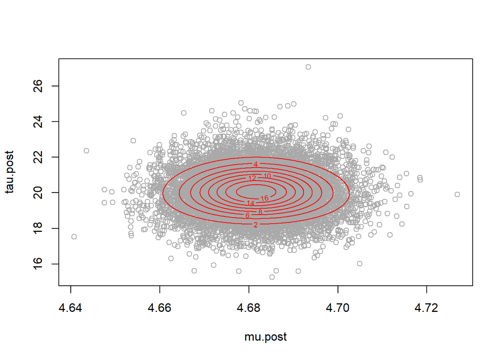

```r
M=10000
tau.post=rgamma(M,shape=a.ast/2,rate=b.ast/2)
mu.post=rnorm(M,mean=m.ast,sd=sqrt(1/(c.ast*tau.post)))
plot(mu.post,tau.post,col="darkgrey")
NGacontour(mu,tau,m.ast,c.ast,a.ast,b.ast,col="red",add=T)
```

With this sample from the joint posterior distribution we can obtain the 95% credible interval for $\mu$:

```r
quantile(mu.post,c(0.025,0.975))
```

```
##     2.5%    97.5%
## 4.662410 4.701198
```

And also a 95% credible interval for $\tau$:

```r
quantile(tau.post,c(0.025,0.975))
```

```
##     2.5%    97.5%
## 17.61692 22.56752
```

### Predictive Probabilities

Supposing we want to estimate the predictive probability that a future value of a Glucose $X_{n+1}$ is larger than a value $Y_i$ of glucose, given the observed Glucose values:

$$\Pr\left(X_{n+1}\gt log(Y_i)\mid \text{data}\right)$$

If we assume a lognormal-gamma for ($\mu, \tau$), the predictive density is ascaled, shifted Student distribution:

$$\log(X_{n+1})\mid\text{data}\sim\text{SS-Student}\left(m^*,\frac{(c^*+1)b^*}{c^*a^*},a^*\right)$$

We can obtain an approximation of the predictive density and compare it with the observed data of log-Glucose:

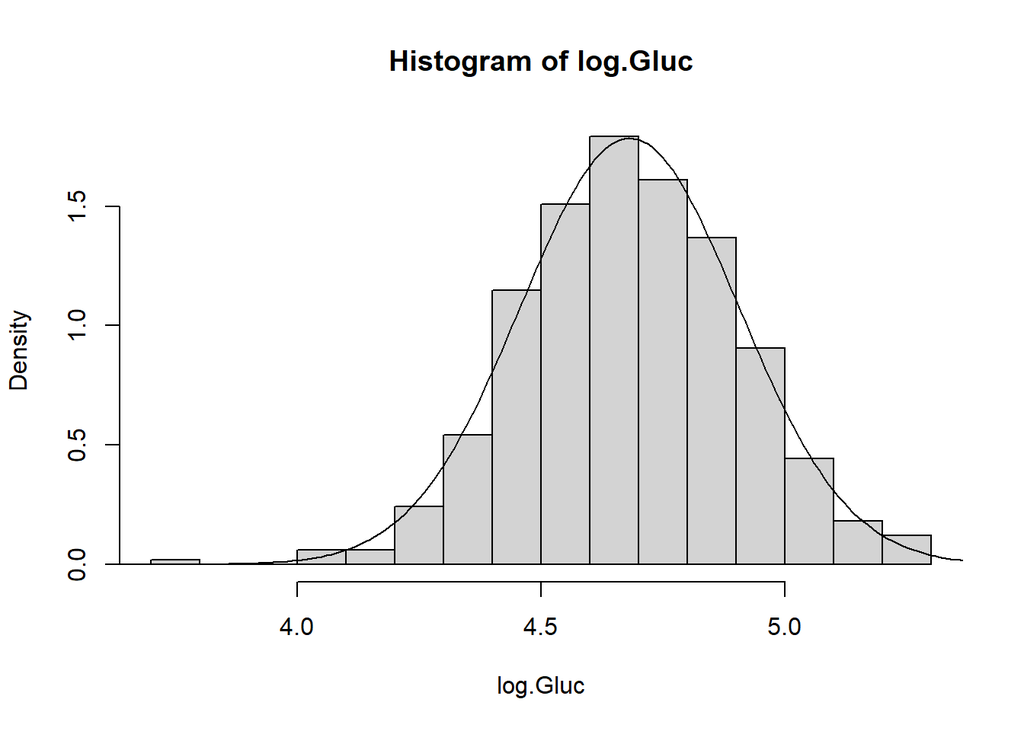

```r
hist(log.Gluc,freq=F, breaks=20)
x.axis=seq(0,200,by=0.01)
pred.mean=m.ast
scale=(c.ast+1)*b.ast/(c.ast*a.ast)
lines(x.axis,dt((x.axis-pred.mean)/sqrt(scale),a.ast)/sqrt(scale))
```

The distribution samples really good the observed data

We can plot it with the observed data of the log-Glucose of Diabetic people:

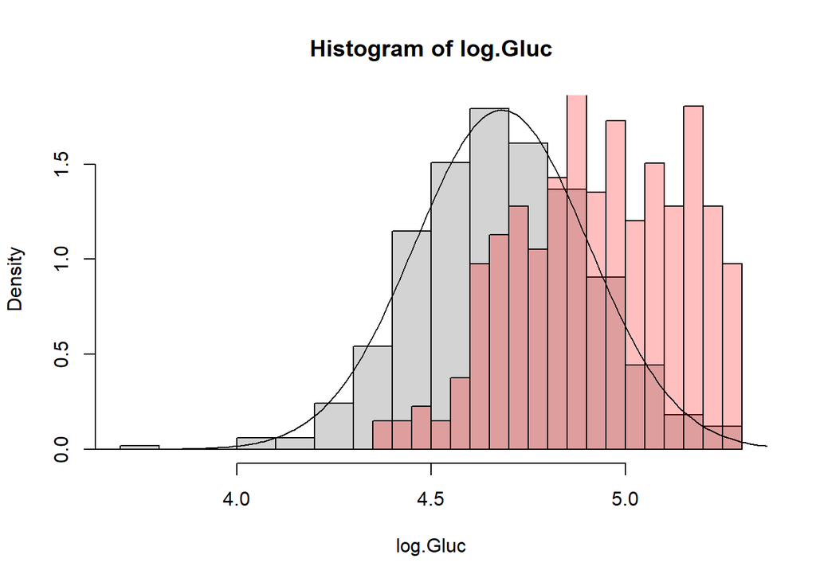

```r
hist(log.Gluc,freq=F, breaks=20)
hist(log(Glucose[y==1][Glucose[y==1] > 0]), freq=F, breaks=20, add=T, col=rgb(1,0,0,1/4))
x.axis=seq(0,200,by=0.01)
pred.mean=m.ast
scale=(c.ast+1)*b.ast/(c.ast*a.ast)
lines(x.axis,dt((x.axis-pred.mean)/sqrt(scale),a.ast)/sqrt(scale))
```

We can compare the empirical cds with the predictive cdf:

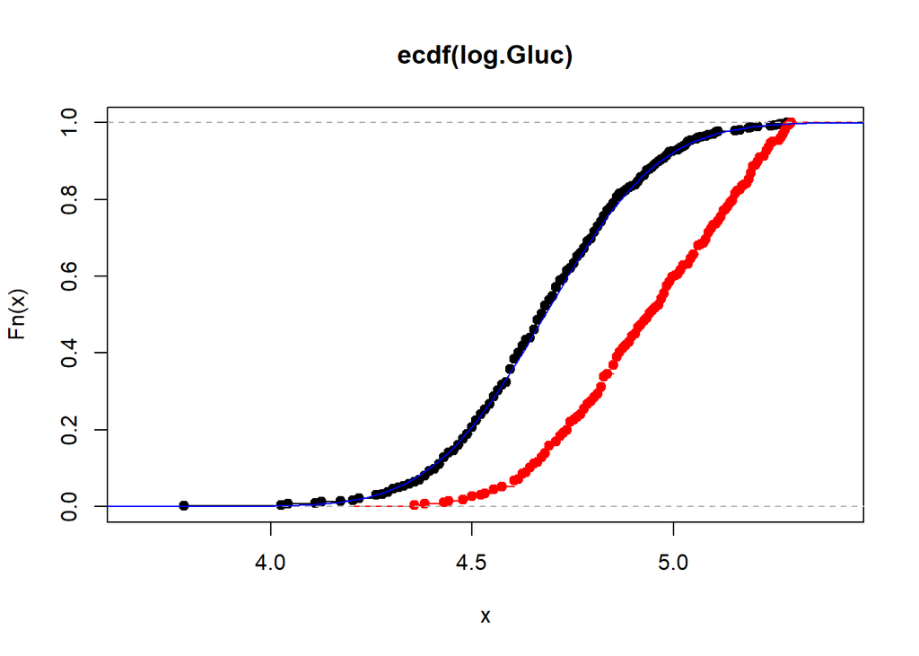

```r
plot(ecdf(log.Gluc))
plot(ecdf(log(Glucose[y==1][Glucose[y==1] > 0])), add=T, col='red')
lines(x.axis,pt((x.axis-pred.mean)/sqrt(scale),a.ast), col='blue')
```

We can obtain the predictive probability that a non-diabetic person has a Glucose level higher than 160:

```r
1-pt((log(160)-pred.mean)/sqrt(scale),a.ast)
```

```
## [1] 0.03938783
```

Is really low, which means that is strange for a Non-diabetic person to have a Glucose level (in the tolerance test) higher than 160, which can be an extreme values (which can be related to a Diabetes value).

We can obtain a sample of predictive glucose values, by applying the exponent of the posterior mean and posterior standard deviation of the lognormal distribution:

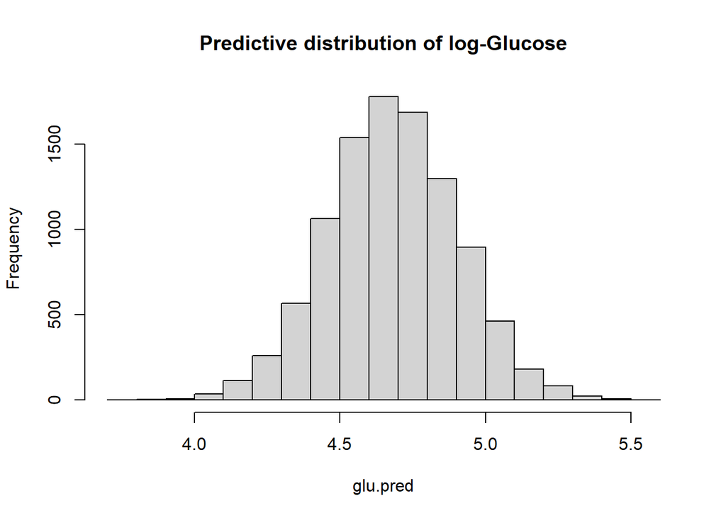

```r
M=10000
glu.pred=rnorm(M,mean=mu.post, sd=1/sqrt(tau.post))
hist(glu.pred, breaks=20 , main="Predictive distribution of log-Glucose")
```

We can obtain the predictive distributions, with the real values of the glucose, by applying the exponent:

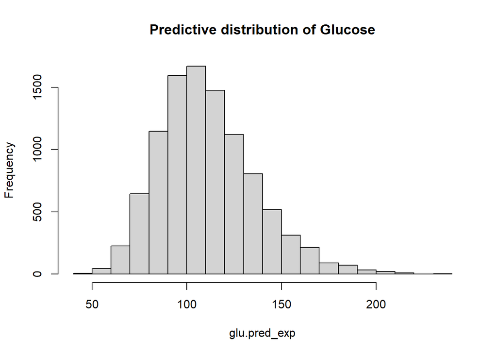

```r
M=10000
glu.pred_exp=exp(rnorm(M,mean=mu.post, sd=1/sqrt(tau.post)))
hist(glu.pred_exp, breaks=20 , main="Predictive distribution of Glucose")
```

In order to obtain the real values of the Glucose, and not the logarithm, we apply the exponent:

We can observe that the mean value of the Glucose for Non-Diabetic people is:

```r
exp(mean(glu.pred))
```

```
## [1] 107.943
```

We can interpretated the predictive intervals as the values that are inside the range of normal values for Non-diabetic people, which means that if the glucose is higher than those values, then the patient may have diabetes.

If we choose a predictive interval of 5%, the normal values of the glucose are between:

```r
exp(quantile(glu.pred, c(0.025, 0.975)))
```

```
##      2.5%     97.5%
##  69.60095 166.57647
```

If we choose a right confidence interval of 5% and 10%, the normal values of glucose are between:

```r
exp(quantile(glu.pred, c(0.95)))
```

```
##      95%
## 155.4193
```

```r
exp(quantile(glu.pred, c(0.9)))
```

```
##      90%
## 143.4523
```

And the predictive probability of a non diabetic patient having a glucose value higher than 160 is:

```r
mean(glu.pred > log(160))
```

```
## [1] 0.0383
```

[figure not shown]

Glucose Chart

We can compare with the medical values, and observe that the outliers, or not significant values in the Predictive Distribution correspond to values of the “Glucose Tolerance Levels” to not normal values, but values related to pre-diabetes or diabetes. So we can say that our inference makes sense.

## Bayesian Logistic Regression

We are going to plot the boxplots for each variable in order to observe how are different values for Diabetic people and Non-diabetic people

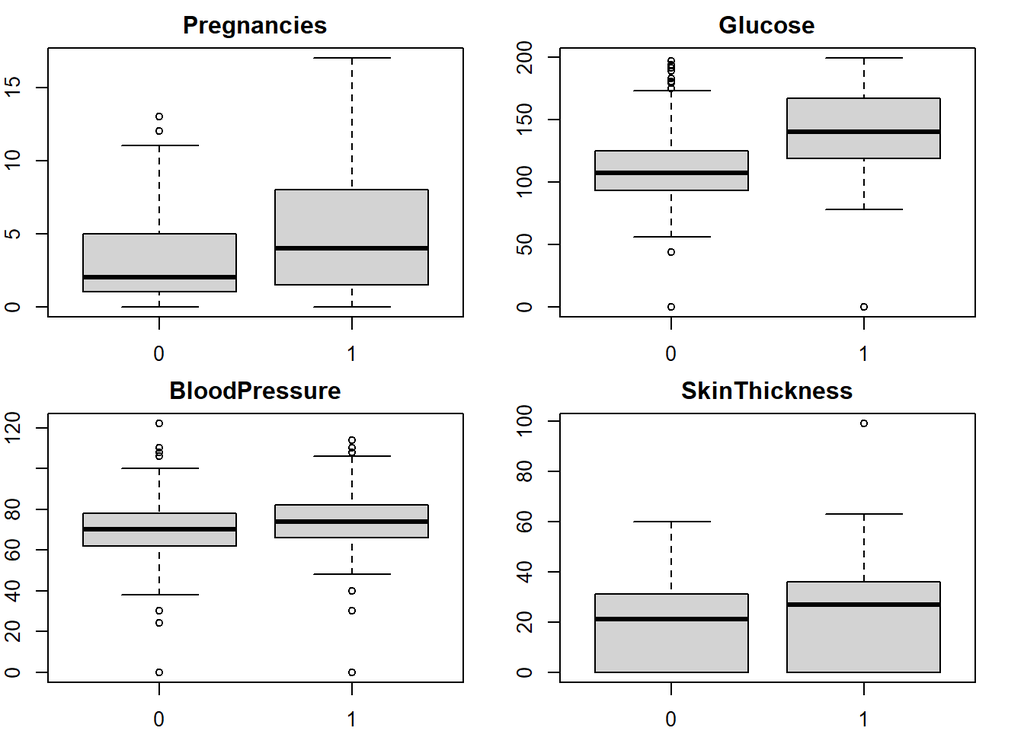

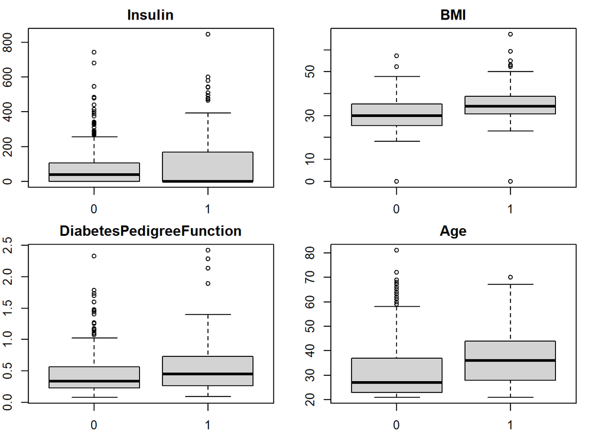

```r
par(mfrow=c(2,2))
par(mar = rep(2, 4))
par(mfrow = c(2,2))
for( i in 1:8){
  boxplot(X[,i]~y, main = names(X)[i])
}
```

We can observe that when a person has higher Glucose levels it is more associated with Diabetes. So using this variable we can create a first approach of an Uni-variate Bayesian Logistic Regression of the probability of failure, explained by the Glucose levels of a persona

### Uni-variate Bayesian Logistic Regression

We assume a logistic regression for this problem:

We set $y_i =1$ to a person $i$ with Diabetes and $y_i =0$ if a person $i$ doesn’t have Diabetes:
$$y_i\mid p_i\sim\text{Bernoulli}(p_i)$$
where $p_i$ denotes the diabetes probability of the person $i$, such that,
$$\log\frac{p_i}{1-p_i}= \alpha+\beta x_i$$

where $x_i$ is the Glucose level of the person$i$

We can achieve this using the MCMCpack that contains the MCMC algorithm for obtaining a Bayesian Logistic Regression:

```r
library(MCMCpack)
logit.mcmc <- MCMClogit(y.bin~Glucose,burnin=5000, mcmc=20000, thin = 10,data=data)
```

We can plot the trace of convergence and the posterior densities of the intercept $\alpha$ and the slope $\beta$:

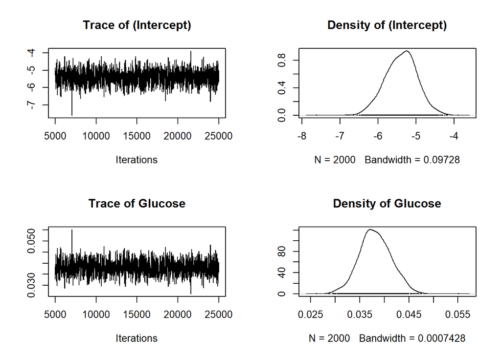

```r
plot(logit.mcmc)
```

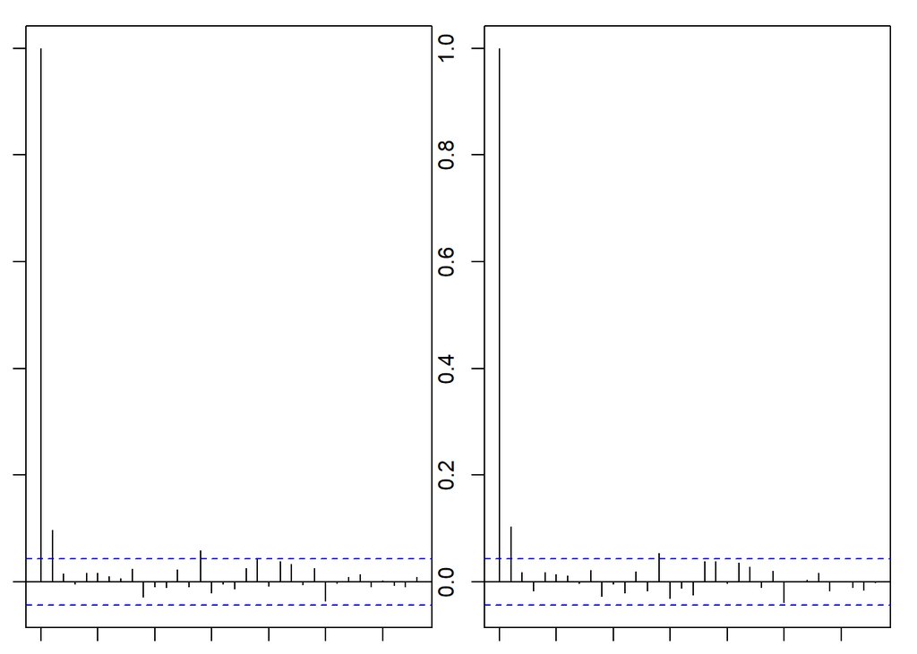

```r
par(mfrow=c(1,2))
par(mar = rep(1, 4))
acf(logit.mcmc[,1], main='ACF of Intercept')
acf(logit.mcmc[,2], main='ACF of Glucose Coeff')
```

```r
summary(logit.mcmc)
```

```
##
## Iterations = 5001:24991
## Thinning interval = 10
## Number of chains = 1
## Sample size per chain = 2000
##
## 1. Empirical mean and standard deviation for each variable,
##    plus standard error of the mean:
##
##                 Mean       SD  Naive SE Time-series SE
## (Intercept) -5.38937 0.419673 9.384e-03      0.0103414
## Glucose      0.03819 0.003232 7.227e-05      0.0000802
##
## 2. Quantiles for each variable:
##
##                 2.5%      25%      50%      75%    97.5%
## (Intercept) -6.23301 -5.66876 -5.36851 -5.10551 -4.57348
## Glucose      0.03185  0.03605  0.03804  0.04034  0.04447
```

We can compare it with a classical Logistic Regression

```r
fit = glm(y~Glucose,family = "binomial")
summary(fit)
```

```
##
## Call:
## glm(formula = y ~ Glucose, family = "binomial")
##
## Deviance Residuals:
##     Min       1Q   Median       3Q      Max
## -2.1096  -0.7837  -0.5365   0.8566   3.2726
##
## Coefficients:
##              Estimate Std. Error z value Pr(>|z|)
## (Intercept) -5.350080   0.420827  -12.71   <2e-16 ***
## Glucose      0.037873   0.003252   11.65   <2e-16 ***
## ---
## Signif. codes:  0 '***' 0.001 '**' 0.01 '*' 0.05 '.' 0.1 ' ' 1
##
## (Dispersion parameter for binomial family taken to be 1)
##
##     Null deviance: 993.48  on 767  degrees of freedom
## Residual deviance: 808.72  on 766  degrees of freedom
## AIC: 812.72
##
## Number of Fisher Scoring iterations: 4
```

The results are very similar.

But the advantage of a Bayesian Logistic Regression is that we can obtain a posterior distribution of the probability of a person having diabetes. For example, we can obtain the posterior distribution of the probability of Diabetes of someone with glucose level of 170 mg/dL

The trace and the density of probability looks good:

```r
library(boot)
```

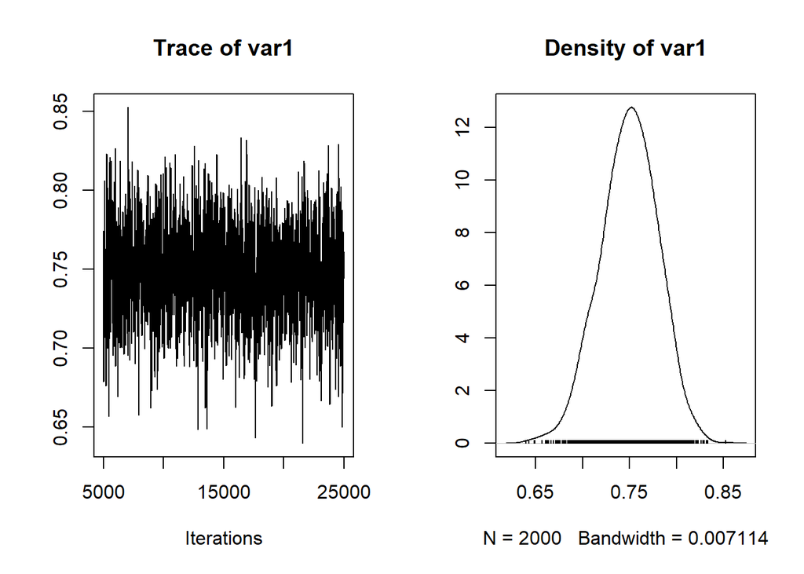

```r
glucose_level = 170
diabetes.prob=inv.logit(logit.mcmc[,1]+glucose_level*logit.mcmc[,2])
plot(diabetes.prob)
```

We can obtain a summary of the probability of a person having diabetes with a glucose level of 170 mg/dL. With the Bayesian Logistic Regression we can obtain the quantiles, that can be used for evaluate the veracity or significance of the probability.

```r
summary(diabetes.prob)
```

```
##
## Iterations = 5001:24991
## Thinning interval = 10
## Number of chains = 1
## Sample size per chain = 2000
##
## 1. Empirical mean and standard deviation for each variable,
##    plus standard error of the mean:
##
##           Mean             SD       Naive SE Time-series SE
##      0.7494503      0.0307307      0.0006872      0.0007751
##
## 2. Quantiles for each variable:
##
##   2.5%    25%    50%    75%  97.5%
## 0.6886 0.7295 0.7505 0.7706 0.8057
```

And we can plot the probability distribution, for a better visualization of the results:

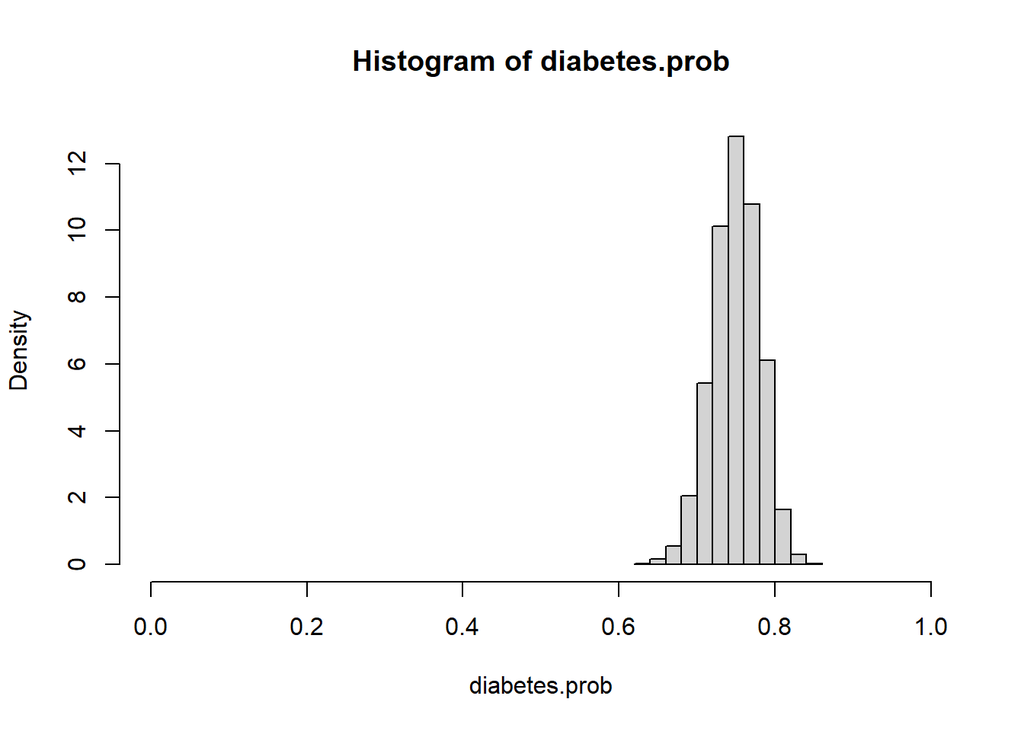

```r
hist(diabetes.prob,freq=F, xlim = c(0,1))
```

And we can obtain the mean probability, the median probability and the quantiles for the probability

```r
mean(diabetes.prob)
```

```
## [1] 0.7494503
```

```r
median(diabetes.prob)
```

```
## [1] 0.7504718
```

```r
quantile(diabetes.prob,c(0.025,0.975))
```

```
##      2.5%     97.5%
## 0.6885549 0.8057433
```

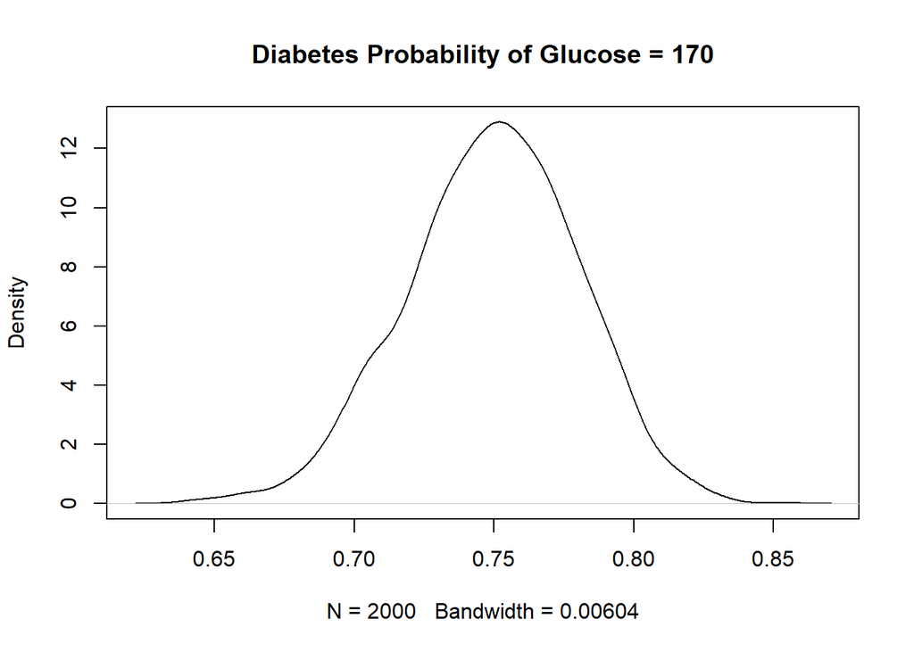

```r
y.pred=rbinom(1000,size=1,prob=diabetes.prob)

plot(density(diabetes.prob), main = "Diabetes Probability of Glucose = 170")
```

### Multi-variate Logistic Regression

We assume a logistic regression for this problem:

We set $y_i =1$ to a person $i$ with Diabetes and $y_i =0$ if a person $i$ doesn’t have Diabetes:

$$y_i\mid p_i\sim\text{Bernoulli}(p_i)$$
where $p_i$ denotes the diabetes probability of the person $i$, such that,
$$\log\frac{p_i}{1-p_i}= \alpha+X_i\beta$$
where $X_i$ is the variables levels of a person (Pregnancies, Glucose, Blood Pressure, BMI, Diabetes Pedigree Function, Skin Thickness, Insulin and Age)$i$

```r
logit.mcmc <- MCMClogit(y.bin~Pregnancies + Glucose + BloodPressure + BMI + DiabetesPedigreeFunction +SkinThickness + Insulin + Age,
                        burnin=2000, mcmc=15000, thin =20, data=X)
```

We can evaluate the trace of the convergence:

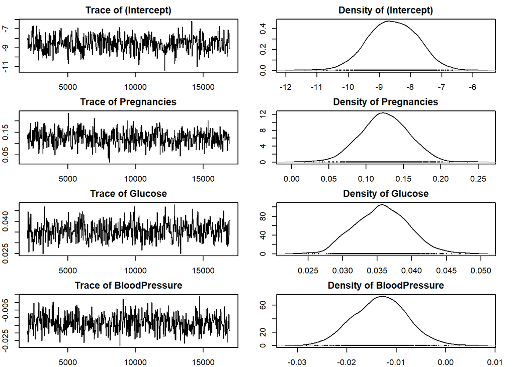

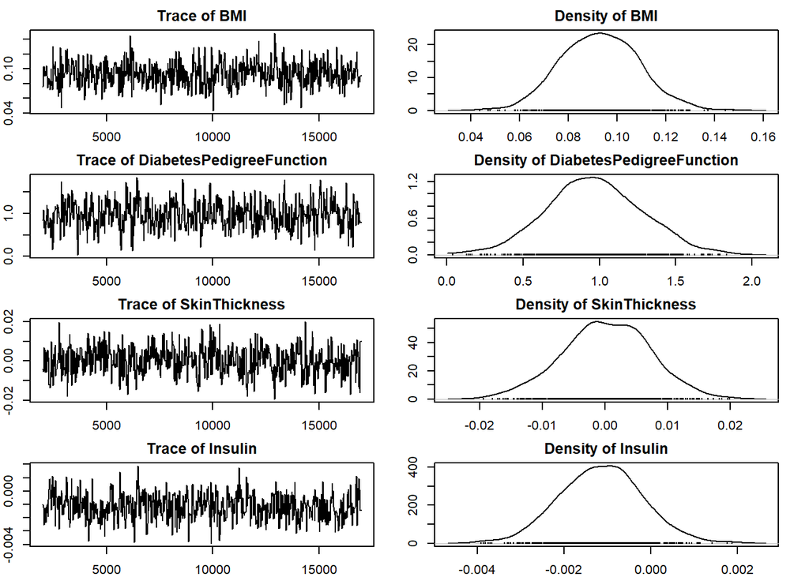

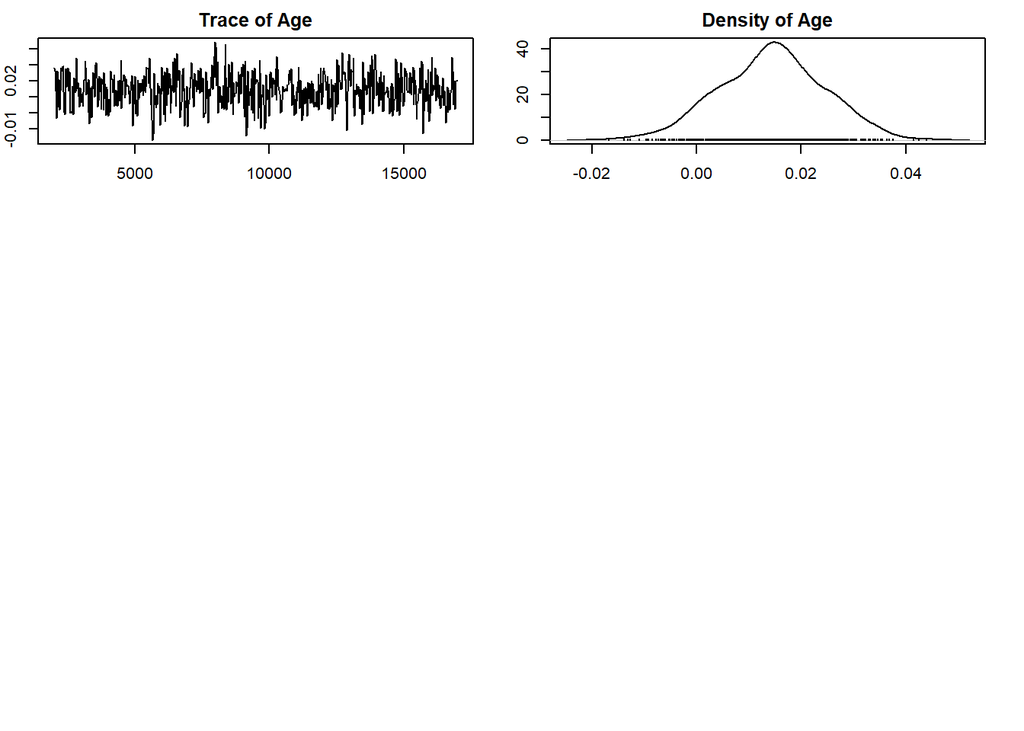

```r
par(mar = rep(2, 4))
par(mfrow = c(4,2))
plot(logit.mcmc)
```

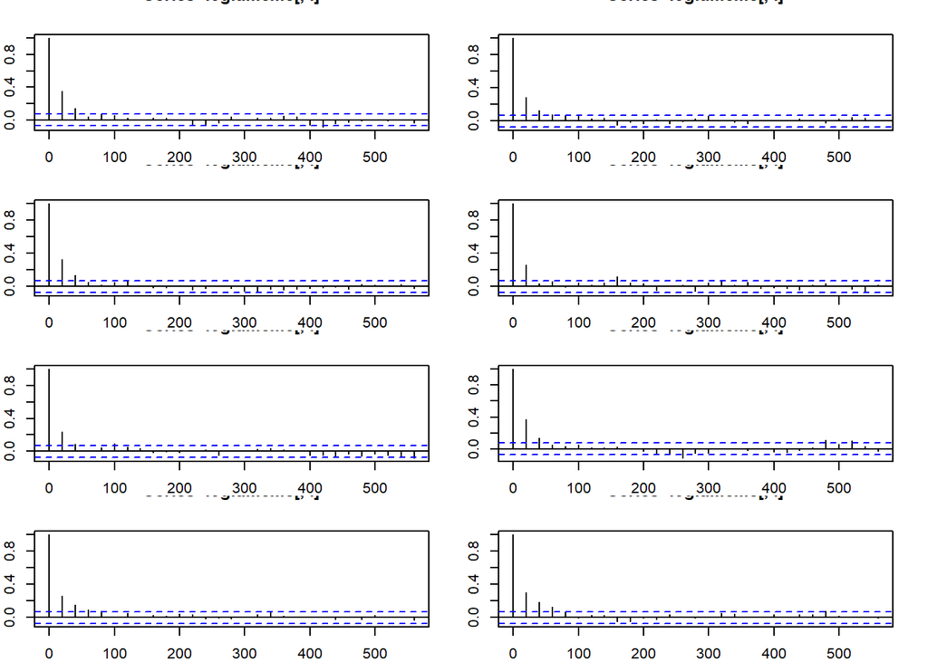

```r
par(mfrow=c(4,2))
par(mar = rep(2, 4))
for(i in 1:8){
  acf(logit.mcmc[,i])
}
```

```r
summary(logit.mcmc)
```

```
##
## Iterations = 2001:16981
## Thinning interval = 20
## Number of chains = 1
## Sample size per chain = 750
##
## 1. Empirical mean and standard deviation for each variable,
##    plus standard error of the mean:
##
##                                Mean        SD  Naive SE Time-series SE
## (Intercept)              -8.5747320 0.7677167 2.803e-02      0.0407173
## Pregnancies               0.1245477 0.0314623 1.149e-03      0.0015427
## Glucose                   0.0356545 0.0037729 1.378e-04      0.0001942
## BloodPressure            -0.0132368 0.0052418 1.914e-04      0.0002978
## BMI                       0.0928938 0.0157157 5.739e-04      0.0007336
## DiabetesPedigreeFunction  0.9664493 0.3092234 1.129e-02      0.0166744
## SkinThickness             0.0001905 0.0068280 2.493e-04      0.0003578
## Insulin                  -0.0011499 0.0009399 3.432e-05      0.0000549
## Age                       0.0143198 0.0098967 3.614e-04      0.0004912
##
## 2. Quantiles for each variable:
##
##                                2.5%       25%        50%       75%      97.5%
## (Intercept)              -10.048641 -9.107238 -8.5759392 -8.032756 -7.1444427
## Pregnancies                0.064340  0.103693  0.1243840  0.146503  0.1837644
## Glucose                    0.028841  0.032979  0.0356486  0.038236  0.0431591
## BloodPressure             -0.023403 -0.016992 -0.0130876 -0.009677 -0.0027044
## BMI                        0.063128  0.081782  0.0928675  0.103839  0.1244017
## DiabetesPedigreeFunction   0.383069  0.764159  0.9618602  1.168481  1.5461657
## SkinThickness             -0.013331 -0.004230  0.0003047  0.004929  0.0132726
## Insulin                   -0.002904 -0.001775 -0.0011600 -0.000555  0.0006867
## Age                       -0.005109  0.007546  0.0144816  0.020424  0.0337660
```

We can observe that the coefficients for the variables `SkinThickness`, `Insulin` and `Age` are not significant, so we can delete them.

```r
logit.mcmc <- MCMClogit(y.bin~Glucose + BloodPressure +
                          BMI + DiabetesPedigreeFunction,
                        burnin=2000, mcmc=15000, thin =20, data=data)

summary(logit.mcmc)
```

```
##
## Iterations = 2001:16981
## Thinning interval = 20
## Number of chains = 1
## Sample size per chain = 750
##
## 1. Empirical mean and standard deviation for each variable,
##    plus standard error of the mean:
##
##                               Mean       SD  Naive SE Time-series SE
## (Intercept)              -7.508366 0.644855 0.0235468      0.0268107
## Glucose                   0.035687 0.003208 0.0001172      0.0001172
## BloodPressure            -0.007219 0.004974 0.0001816      0.0002045
## BMI                       0.077156 0.013561 0.0004952      0.0005348
## DiabetesPedigreeFunction  0.846151 0.277776 0.0101429      0.0112384
##
## 2. Quantiles for each variable:
##
##                              2.5%      25%       50%       75%     97.5%
## (Intercept)              -8.77844 -7.92815 -7.458505 -7.115980 -6.252596
## Glucose                   0.02923  0.03349  0.035630  0.037880  0.041972
## BloodPressure            -0.01644 -0.01037 -0.007341 -0.004078  0.003128
## BMI                       0.05121  0.06857  0.076041  0.085656  0.106714
## DiabetesPedigreeFunction  0.30570  0.65614  0.852480  1.023637  1.383308
```

We can compare it with a Classical Logistic Regression

```r
fit = glm(y~Pregnancies + Glucose + BloodPressure + BMI + DiabetesPedigreeFunction,family = "binomial")
summary(fit)
```

```
##
## Call:
## glm(formula = y ~ Pregnancies + Glucose + BloodPressure + BMI +
##     DiabetesPedigreeFunction, family = "binomial")
##
## Deviance Residuals:
##     Min       1Q   Median       3Q      Max
## -2.7931  -0.7362  -0.4188   0.7251   2.9555
##
## Coefficients:
##                           Estimate Std. Error z value Pr(>|z|)
## (Intercept)              -7.954952   0.675823 -11.771  < 2e-16 ***
## Pregnancies               0.153492   0.027835   5.514  3.5e-08 ***
## Glucose                   0.034658   0.003394  10.213  < 2e-16 ***
## BloodPressure            -0.012007   0.005031  -2.387  0.01700 *
## BMI                       0.084832   0.014125   6.006  1.9e-09 ***
## DiabetesPedigreeFunction  0.910628   0.294027   3.097  0.00195 **
## ---
## Signif. codes:  0 '***' 0.001 '**' 0.01 '*' 0.05 '.' 0.1 ' ' 1
##
## (Dispersion parameter for binomial family taken to be 1)
##
##     Null deviance: 993.48  on 767  degrees of freedom
## Residual deviance: 728.56  on 762  degrees of freedom
## AIC: 740.56
##
## Number of Fisher Scoring iterations: 5
```

We plot the trace of convergence and the autocorrelations, and observe that there is no autocorrelation in the coefficients

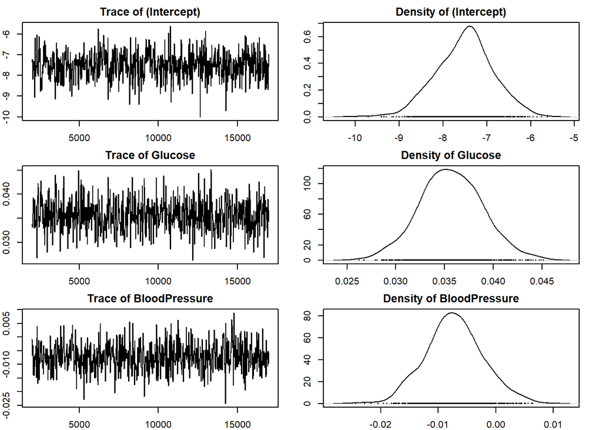

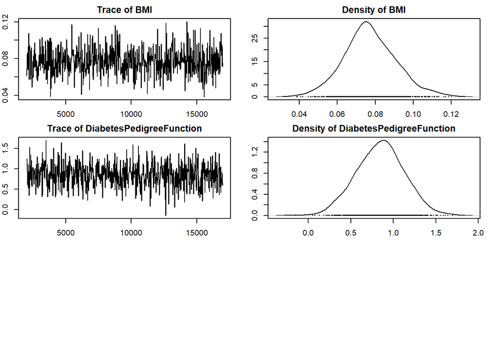

```r
par(mar = rep(2, 4))
par(mfrow = c(4,2))
plot(logit.mcmc)
```

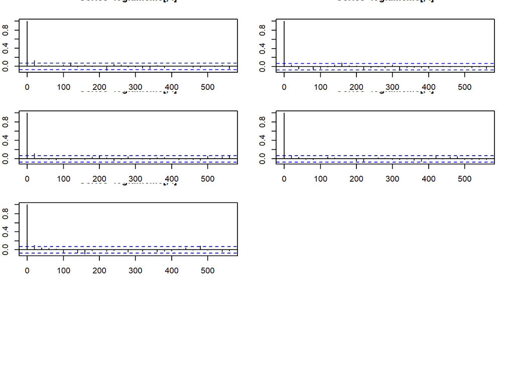

```r
# par(mfrow=c(5,1))
# # par(mar = rep(1,5))
# par(mfrow=c(5,1))
par(mar = rep(2, 4))
par(mfrow = c(4,2))
for(i in 1:5){
  acf(logit.mcmc[,i])
}
```